# Project Topic

## Getting Investment Insights By Analyzing Nifty 50 Data.

# Problem Statement

Link to Dataset --[click here](https://www.kaggle.com/datasets/setseries/nifty50-stocks-dataset20102021/data?select=Final-50-stocks.csv)

### A investment consulting firm has a dataset of Nifty 50 stocks and they want to gain actionable insights from this dataset. After gaining insights they want to invest and guide there clients to buid a profitable portfolio. Hence they have hired me as Data Scientist to Analyze the dataset in detail and come up with some potential insights.

# Import Libraries

```python
import pandas as pd
import seaborn as abc
import datetime as dt
import numpy as np
import matplotlib.pyplot as plot
%matplotlib inline
import warnings
warnings.filterwarnings('ignore')
```

```python
nif50 = pd.read_csv("datasets/Final-50-stocks.csv")
```

# Data Exploration

```python
nif50.info()
```

```
<class 'pandas.core.frame.DataFrame'>
RangeIndex: 2711 entries, 0 to 2710
Data columns (total 47 columns):
 #   Column        Non-Null Count  Dtype
---  ------        --------------  -----
 0   DATE          2711 non-null   object
 1   TATASTEEL     2711 non-null   float64
 2   WIPRO         2711 non-null   float64
 3   TITAN         2711 non-null   float64
 4   ULTRACEMO     2711 non-null   float64
 5   TECHM         2711 non-null   float64
 6   RELIANCE      2711 non-null   float64
 7   SHREECEM      2711 non-null   float64
 8   SUNPHARMA     2711 non-null   float64
 9   TATAMOTORS    2711 non-null   float64
```

[output cut: 39 more lines]

```python
nif50.dtypes
```

```
DATE             object
TATASTEEL       float64
WIPRO           float64
TITAN           float64
ULTRACEMO       float64
TECHM           float64
RELIANCE        float64
SHREECEM        float64
SUNPHARMA       float64
TATAMOTORS      float64
TCS             float64
SBIN            float64
NESTLEIND       float64
NTPC            float64
M&M             float64
MARUTI          float64
ONGC            float64
POWERGRID       float64
JSWSTEEL        float64
KOTAKBANK       float64
LT              float64
ICICIBANK       float64
INDUSBANK       float64
INFY            float64
IOC             float64
ITC             float64
HEROMOTOCO      float64
HINDALCO        float64
HINDUNILVR      float64
HCLTECH         float64
HDFCBANK        float64
HDFC            float64
DRREDDYS        float64
EICHERMOTOR     float64
GRASIM          float64
CIPLA           float64
COALINDIA       float64
BPCL            float64
BRITANNIA       float64
ADANIPORTS      float64
BAJAJFINSERV    float64
BAJAJFINANCE    float64
BHARTIARTL      float64
AXISBANK        float64
BAJAJ-AUTO      float64
ASIANPAINT      float64
UPL             float64
dtype: object
```

```python
nif50.columns
```

```
Index(['DATE', 'TATASTEEL', 'WIPRO', 'TITAN', 'ULTRACEMO', 'TECHM', 'RELIANCE',
       'SHREECEM', 'SUNPHARMA', 'TATAMOTORS', 'TCS', 'SBIN', 'NESTLEIND',
       'NTPC', 'M&M', 'MARUTI', 'ONGC', 'POWERGRID', 'JSWSTEEL', 'KOTAKBANK',
       'LT', 'ICICIBANK', 'INDUSBANK', 'INFY', 'IOC', 'ITC', 'HEROMOTOCO',
       'HINDALCO', 'HINDUNILVR', 'HCLTECH', 'HDFCBANK', 'HDFC', 'DRREDDYS',
       'EICHERMOTOR', 'GRASIM', 'CIPLA', 'COALINDIA', 'BPCL', 'BRITANNIA',
       'ADANIPORTS', 'BAJAJFINSERV', 'BAJAJFINANCE', 'BHARTIARTL', 'AXISBANK',
       'BAJAJ-AUTO', 'ASIANPAINT', 'UPL'],
      dtype='object')
```

# Data Processing and Cleaning

```python
nif50['DATE']=pd.to_datetime(nif50.DATE)
nif50['Year']=nif50.DATE.dt.year
nif50['Month']=nif50.DATE.dt.month
```

#### In this we converted the values in the date, column of the dataframe nif50 into datetime objects. Then we create a new column named month, year in the dataframe nif50.

```python
nif50.HEROMOTOCO.isnull().value_counts()
```

```
False    2509
True      202
Name: HEROMOTOCO, dtype: int64
```

#### This applies a boolean mask to the column 'HEROMOTOCO', returning a boolean Series where each element is True if the corresponding value in the column is NaN (null), and False otherwise.

```python
nif50.HEROMOTOCO.fillna(nif50.HEROMOTOCO.mean(),inplace=True)
nif50.HEROMOTOCO
```

```
0       2672.184277
1       2672.184277
2       2672.184277
3       2672.184277
4       2672.184277
           ...
2706    2836.300000
2707    3009.000000
2708    2797.050000
2709    2925.200000
2710    2927.800000
Name: HEROMOTOCO, Length: 2711, dtype: float64
```

```python
nif50.COALINDIA.isnull().value_counts()
nif50.COALINDIA.fillna(nif50.COALINDIA.mean(),inplace=True)
nif50.COALINDIA
```

```
0       282.873286
1       320.950000
2       282.873286
3       324.850000
4       282.873286
           ...
2706    147.050000
2707    156.500000
2708    142.200000
2709    190.050000
2710    183.800000
Name: COALINDIA, Length: 2711, dtype: float64
```

```python
nif50.UPL.isnull().value_counts()
nif50.UPL.fillna(nif50.UPL.mean(),inplace=True)
nif50.UPL
```

```
0       572.459622
1       572.459622
2       572.459622
3       572.459622
4       572.459622
           ...
2706    674.600000
2707    838.700000
2708    771.100000
2709    747.450000
2710    747.850000
Name: UPL, Length: 2711, dtype: float64
```

```python
nif50.ADANIPORTS.isnull().value_counts()
nif50.ADANIPORTS.fillna(nif50.ADANIPORTS.mean(),inplace=True)
nif50.ADANIPORTS
```

```
0       331.130855
1       331.130855
2       331.130855
3       331.130855
4       331.130855
           ...
2706    765.450000
2707    846.750000
2708    693.000000
2709    759.000000
2710    812.800000
Name: ADANIPORTS, Length: 2711, dtype: float64
```

```python
nif50.INFY.isnull().value_counts()
nif50.INFY.fillna(nif50.ADANIPORTS.mean(),inplace=True)
nif50.INFY
```

```
0        331.130855
1        331.130855
2        331.130855
3        331.130855
4        331.130855
           ...
2706    1339.550000
2707    1424.300000
2708    1677.250000
2709    1709.200000
2710    1715.750000
Name: INFY, Length: 2711, dtype: float64
```

#### This replaces missing (NaN) values with a specified value and calculates the mean value of the non-missing values and after that the parameter specifies that the changes should be applied directly to nif50.

```python
clean_data = nif50.isna().sum().sum()
print("Null Values in dataset - ", clean_data)
```

```
Null Values in dataset -  0
```

#### Therefore all Null Values are removed.

# Data Visualization

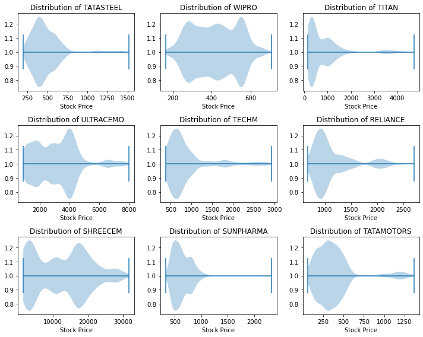

```python
image_width = 10
image_height = 8

fig, axes = plot.subplots(nrows=3, ncols=3, figsize=(image_width, image_height))
axes = axes.flatten()

for i, ax in zip(range(1, 10), axes):
    ax.violinplot(nif50.iloc[:, i], vert=False)
    ax.set_title(f"Distribution of {nif50.columns[i]}")
    ax.set_xlabel("Stock Price")

plot.tight_layout()
plot.show()
```